# Uber Data Analysis

### About Dataset

Geography: USA, Sri Lanka and Pakistan

Time period: January - December 2016

Unit of analysis: Drives

Total Drives: 1,155

Total Miles: 12,204

Dataset: The dataset contains Start Date, End Date, Start Location, End Location, Miles Driven and Purpose of drive (Business, Personal, Meals, Errands, Meetings, Customer Support etc.)

```python
#import libraries

import pandas as pd
import numpy as np
import matplotlib.pyplot as plt
import seaborn as sns
```

```python
#read csv
df=pd.read_csv('C:\\Users\\cvchy\\Downloads\\My Uber Drives - 2016.csv')
```

## Understanding the Data

we need to understand the data for the data cleaning process. Here we use Pandas, Numpy, Matplotlib and seaborn for visulaization

```python
# printing first five rows
df.head()
```

|  | START_DATE* | END_DATE* | CATEGORY* | START* | STOP* | MILES* | PURPOSE* |
| --- | --- | --- | --- | --- | --- | --- | --- |
| 0 | 1/1/2016 21:11 | 1/1/2016 21:17 | Business | Fort Pierce | Fort Pierce | 5.1 | Meal/Entertain |
| 1 | 1/2/2016 1:25 | 1/2/2016 1:37 | Business | Fort Pierce | Fort Pierce | 5.0 | NaN |
| 2 | 1/2/2016 20:25 | 1/2/2016 20:38 | Business | Fort Pierce | Fort Pierce | 4.8 | Errand/Supplies |
| 3 | 1/5/2016 17:31 | 1/5/2016 17:45 | Business | Fort Pierce | Fort Pierce | 4.7 | Meeting |
| 4 | 1/6/2016 14:42 | 1/6/2016 15:49 | Business | Fort Pierce | West Palm Beach | 63.7 | Customer Visit |

```python
#printing null values
df.isnull().sum()
```

```
START_DATE*      0
END_DATE*        1
CATEGORY*        1
START*           1
STOP*            1
MILES*           0
PURPOSE*       503
dtype: int64
```

```python
#information of the dataset
df.info()
```

```
<class 'pandas.core.frame.DataFrame'>
RangeIndex: 1156 entries, 0 to 1155
Data columns (total 7 columns):
 #   Column       Non-Null Count  Dtype
---  ------       --------------  -----
 0   START_DATE*  1156 non-null   object
 1   END_DATE*    1155 non-null   object
 2   CATEGORY*    1155 non-null   object
 3   START*       1155 non-null   object
 4   STOP*        1155 non-null   object
 5   MILES*       1156 non-null   float64
 6   PURPOSE*     653 non-null    object
dtypes: float64(1), object(6)
memory usage: 63.3+ KB
```

```python
#printing columns
df.columns
```

```
Index(['START_DATE*', 'END_DATE*', 'CATEGORY*', 'START*', 'STOP*', 'MILES*',
       'PURPOSE*'],
      dtype='object')
```

```python
#data types of the columns in the dataset
df.dtypes
```

```
START_DATE*     object
END_DATE*       object
CATEGORY*       object
START*          object
STOP*           object
MILES*         float64
PURPOSE*        object
dtype: object
```

```python
#print last 5 rows
df.tail()
```

|  | START_DATE* | END_DATE* | CATEGORY* | START* | STOP* | MILES* | PURPOSE* |
| --- | --- | --- | --- | --- | --- | --- | --- |
| 1151 | 12/31/2016 13:24 | 12/31/2016 13:42 | Business | Kar?chi | Unknown Location | 3.9 | Temporary Site |
| 1152 | 12/31/2016 15:03 | 12/31/2016 15:38 | Business | Unknown Location | Unknown Location | 16.2 | Meeting |
| 1153 | 12/31/2016 21:32 | 12/31/2016 21:50 | Business | Katunayake | Gampaha | 6.4 | Temporary Site |
| 1154 | 12/31/2016 22:08 | 12/31/2016 23:51 | Business | Gampaha | Ilukwatta | 48.2 | Temporary Site |
| 1155 | Totals | NaN | NaN | NaN | NaN | 12204.7 | NaN |

### we can see that last row doesn't have any detailed information so we can remove it

```python
# Remove uncessary data
uber_df = df[:-1]
```

```python
uber_df
```

|  | START_DATE* | END_DATE* | CATEGORY* | START* | STOP* | MILES* | PURPOSE* |
| --- | --- | --- | --- | --- | --- | --- | --- |
| 0 | 1/1/2016 21:11 | 1/1/2016 21:17 | Business | Fort Pierce | Fort Pierce | 5.1 | Meal/Entertain |
| 1 | 1/2/2016 1:25 | 1/2/2016 1:37 | Business | Fort Pierce | Fort Pierce | 5.0 | NaN |
| 2 | 1/2/2016 20:25 | 1/2/2016 20:38 | Business | Fort Pierce | Fort Pierce | 4.8 | Errand/Supplies |
| 3 | 1/5/2016 17:31 | 1/5/2016 17:45 | Business | Fort Pierce | Fort Pierce | 4.7 | Meeting |
| 4 | 1/6/2016 14:42 | 1/6/2016 15:49 | Business | Fort Pierce | West Palm Beach | 63.7 | Customer Visit |
| ... | ... | ... | ... | ... | ... | ... | ... |
| 1150 | 12/31/2016 1:07 | 12/31/2016 1:14 | Business | Kar?chi | Kar?chi | 0.7 | Meeting |
| 1151 | 12/31/2016 13:24 | 12/31/2016 13:42 | Business | Kar?chi | Unknown Location | 3.9 | Temporary Site |
| 1152 | 12/31/2016 15:03 | 12/31/2016 15:38 | Business | Unknown Location | Unknown Location | 16.2 | Meeting |
| 1153 | 12/31/2016 21:32 | 12/31/2016 21:50 | Business | Katunayake | Gampaha | 6.4 | Temporary Site |
| 1154 | 12/31/2016 22:08 | 12/31/2016 23:51 | Business | Gampaha | Ilukwatta | 48.2 | Temporary Site |

1155 rows × 7 columns

```python
uber_df.dtypes
```

```
START_DATE*     object
END_DATE*       object
CATEGORY*       object
START*          object
STOP*           object
MILES*         float64
PURPOSE*        object
dtype: object
```

```python
import datetime
```

```python
uber_df['START_DATE*']=  pd.to_datetime(uber_df['START_DATE*'], infer_datetime_format=True)
```

```python
uber_df['END_DATE*']=  pd.to_datetime(uber_df['END_DATE*'], infer_datetime_format=True)
```

```python
uber_df.dtypes
```

```
START_DATE*    datetime64[ns]
END_DATE*      datetime64[ns]
CATEGORY*              object
START*                 object
STOP*                  object
MILES*                float64
PURPOSE*               object
dtype: object
```

#### Data type of the startdate and enddate has been changed into datetime

# visualization

### visualization helps to understand the problem and get insights through graphs. We use matplotlib and searborn to do visualization

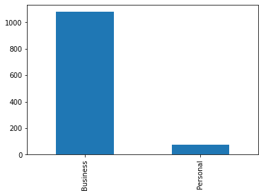

```python
# plot number of trip at each category
x = uber_df['CATEGORY*'].value_counts().plot(kind='bar')
```

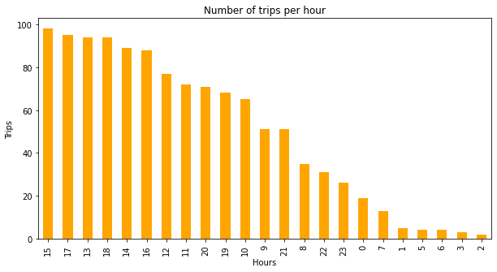

```python
#visualizing the hours in start_date column with the help of bar graph
hours = uber_df['START_DATE*'].dt.hour.value_counts()

hours.plot(kind='bar',color='orange',figsize=(10,5))

plt.xlabel('Hours')
plt.ylabel('Trips')
plt.title('Number of trips per hour')
```

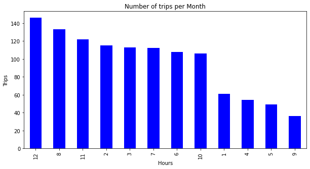

```python
#visualizing the month in end_date coulmn with the help of bar graph
MONTH = uber_df['END_DATE*'].dt.month.value_counts()

MONTH.plot(kind='bar',color='blue',figsize=(10,5))
plt.xlabel('Hours')
plt.ylabel('Trips')
plt.title('Number of trips per Month')
```

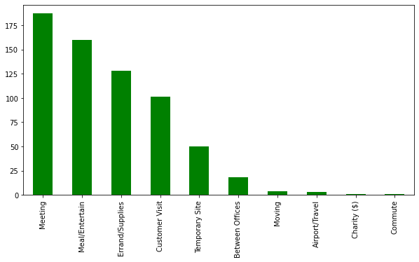

```python
#visualization of purpose column using bar graph
purpose = uber_df['PURPOSE*'].value_counts()
purpose.plot(kind='bar',figsize=(10,5),color='green')
```

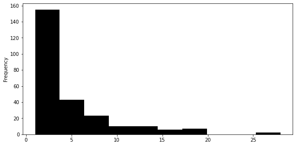

```python
#visulaizing the Miles columns using histogram
miles = uber_df['MILES*'].value_counts()
miles.plot(kind='hist',figsize=(10,5),color='black')
```

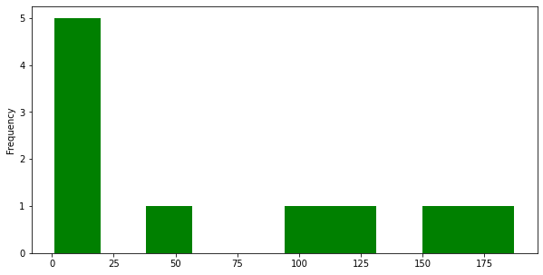

```python
purpose = uber_df['PURPOSE*'].value_counts()
purpose.plot(kind='hist',figsize=(10,5),color='green')
```

```python
#calculating the exact time(minutes) travelled by the uber driver
minutes=[]
uber_df['Duration_Minutes'] = uber_df['END_DATE*'] - uber_df['START_DATE*']
uber_df['Duration_Minutes']
for i in uber_df['Duration_Minutes']:
    minutes.append(i.seconds / 60)

uber_df['Duration_Minutes'] = minutes
```

```python
uber_df['Duration_Minutes']
```

```
0         6.0
1        12.0
2        13.0
3        14.0
4        67.0
        ...
1150      7.0
1151     18.0
1152     35.0
1153     18.0
1154    103.0
Name: Duration_Minutes, Length: 1155, dtype: float64
```

```python
#calculation of speed of a trip by uber drivers

#calculation of hours as per the minutes travelled
uber_df['Duration_hours'] = uber_df['Duration_Minutes'] / 60
uber_df['Speed_KM'] = uber_df['MILES*'] / uber_df['Duration_hours']
uber_df['Speed_KM']
```

```
0       51.000000
1       25.000000
2       22.153846
3       20.142857
4       57.044776
          ...
1150     6.000000
1151    13.000000
1152    27.771429
1153    21.333333
1154    28.077670
Name: Speed_KM, Length: 1155, dtype: float64
```

```python
uber_df.isnull().sum()
```

```
START_DATE*           0
END_DATE*             0
CATEGORY*             0
START*                0
STOP*                 0
MILES*                0
PURPOSE*            502
Duration_Minutes      0
Duration_hours        0
Speed_KM              0
dtype: int64
```

Here we can see null values in purpose column. But we can't replace or delete them without the expert domain suggestion.

# What is the average length of the trip?

```python
# calucationg the average miles travelled
uber_df['MILES*'].mean()
```

```
10.566839826839827
```

# Average number of rides per week or per month?

```python
# calculating the average rides per month
MONTH.mean()
```

```
96.25
```

```python
# calculating the average rides per week

week=MONTH/4
week
week.mean()
```

```
24.0625
```

# Percentage of business vs personal ?

```python
#calculating the percentage of the category column
(uber_df['CATEGORY*'].value_counts() / len(uber_df))*100
```

```
Business    93.333333
Personal     6.666667
Name: CATEGORY*, dtype: float64
```

Here we can see that the most of the uber services is used for the business category i.e.,93% and the least used for the personal category i.e.,6%.

```python
#printing uber_df file

uber_df
```

|  | START_DATE* | END_DATE* | CATEGORY* | START* | STOP* | MILES* | PURPOSE* | Duration_Minutes | Duration_hours | Speed_KM |
| --- | --- | --- | --- | --- | --- | --- | --- | --- | --- | --- |
| 0 | 2016-01-01 21:11:00 | 2016-01-01 21:17:00 | Business | Fort Pierce | Fort Pierce | 5.1 | Meal/Entertain | 6.0 | 0.100000 | 51.000000 |
| 1 | 2016-01-02 01:25:00 | 2016-01-02 01:37:00 | Business | Fort Pierce | Fort Pierce | 5.0 | NaN | 12.0 | 0.200000 | 25.000000 |
| 2 | 2016-01-02 20:25:00 | 2016-01-02 20:38:00 | Business | Fort Pierce | Fort Pierce | 4.8 | Errand/Supplies | 13.0 | 0.216667 | 22.153846 |
| 3 | 2016-01-05 17:31:00 | 2016-01-05 17:45:00 | Business | Fort Pierce | Fort Pierce | 4.7 | Meeting | 14.0 | 0.233333 | 20.142857 |
| 4 | 2016-01-06 14:42:00 | 2016-01-06 15:49:00 | Business | Fort Pierce | West Palm Beach | 63.7 | Customer Visit | 67.0 | 1.116667 | 57.044776 |
| ... | ... | ... | ... | ... | ... | ... | ... | ... | ... | ... |
| 1150 | 2016-12-31 01:07:00 | 2016-12-31 01:14:00 | Business | Kar?chi | Kar?chi | 0.7 | Meeting | 7.0 | 0.116667 | 6.000000 |
| 1151 | 2016-12-31 13:24:00 | 2016-12-31 13:42:00 | Business | Kar?chi | Unknown Location | 3.9 | Temporary Site | 18.0 | 0.300000 | 13.000000 |
| 1152 | 2016-12-31 15:03:00 | 2016-12-31 15:38:00 | Business | Unknown Location | Unknown Location | 16.2 | Meeting | 35.0 | 0.583333 | 27.771429 |
| 1153 | 2016-12-31 21:32:00 | 2016-12-31 21:50:00 | Business | Katunayake | Gampaha | 6.4 | Temporary Site | 18.0 | 0.300000 | 21.333333 |
| 1154 | 2016-12-31 22:08:00 | 2016-12-31 23:51:00 | Business | Gampaha | Ilukwatta | 48.2 | Temporary Site | 103.0 | 1.716667 | 28.077670 |

1155 rows × 10 columns

Now the Dataset is ready for the Model building.